# Combining Augmented Reality and Reproducibilityto convey spatio-temporal results

### SUS Score

To evaluate the results of the usability scale, a score was computed. Each statement gets a score from one (worst) to four (best). The ten scores of each statement are aggregated and multiplied by 2.5. This results in a score ranging from 25 (worst) to 100 (best). The participants rated our application with a score of 76 in average, ranging from 45 to 95, all scores are visible in the figure.

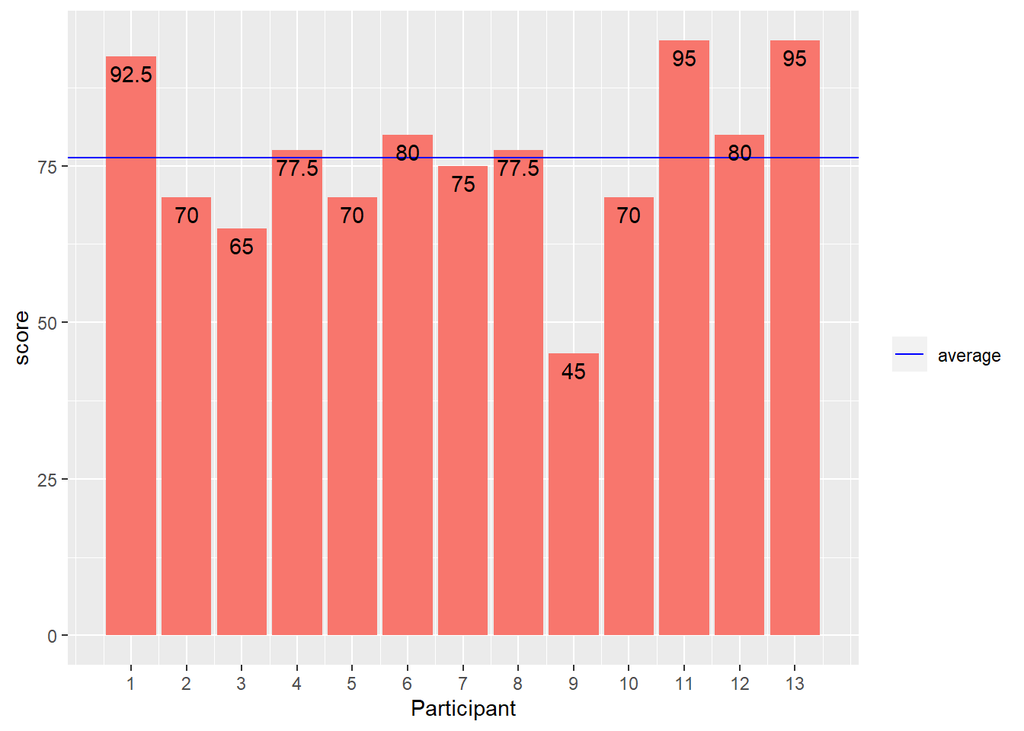

Next to the score, the participants rated the general user friendliness. Five in each case rated the user friendliness as good and excellent. Two rated as fair and one as best imaginable.

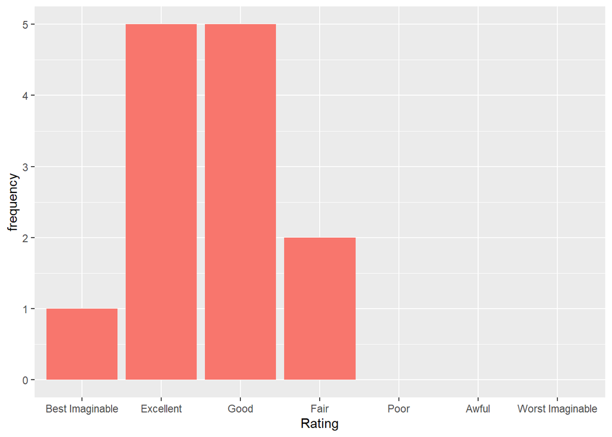